# Taller 2 de Machine Learning Avanzado

Araneda F., Marcela

Reyes G., Álvaro

Sepúlveda M., Danilo

Zegpi D., Diabb

```r
# Dependencias
# install.packages(c("tidyverse", "tidymodels", "ranger", "here", "vip"))

library(tidyverse)
library(tidymodels)
library(here)
titanic_train <- read_csv(here("Machine Learning Avanzado", "train.csv"))
titanic_test <- read_csv(here("Machine Learning Avanzado", "test.csv"))
titanic_train$Survived <- factor(titanic_train$Survived)
```

Primero que todo, se necesita saber cuáles campos tiene `titanic_train` que `titanic_test` no contenga, con el objetivo de evitar *data leakage*.

```r
colnames(titanic_train[!colnames(titanic_train) %in% colnames(titanic_test)])
```

```
## [1] "Survived"
```

La única columna que no se encuentra en el conjunto de prueba es `Survived`. Posteriormente, se examina el dataset de entrenamiento en búsqueda de valores faltantes.

```r
titanic_train %>%
  summarise(across(everything(), ~sum(is.na(.)))) %>%
  pivot_longer(cols = everything(), names_to = "Campo", values_to = "NAs") %>%
  mutate("% de NAs" = round(100 * NAs / nrow(titanic_train), 2)) %>%
  print(n = Inf)
```

```
## # A tibble: 12 x 3
##    Campo         NAs `% de NAs`
##    <chr>       <int>      <dbl>
##  1 PassengerId     0       0
##  2 Survived        0       0
##  3 Pclass          0       0
##  4 Name            0       0
##  5 Sex             0       0
##  6 Age           177      19.9
##  7 SibSp           0       0
##  8 Parch           0       0
##  9 Ticket          0       0
## 10 Fare            0       0
## 11 Cabin         687      77.1
## 12 Embarked        2       0.22
```

De acuerdo al resultado anterior, es necesario tratar con las columnas `Age`, `Cabin` y `Embarked`.

### Tratamiento de valores faltantes

Para el caso de la variable `Embarked` se imputará por la moda, debido a que el 72% de los pasajeros abordaron en Southampton.

El gran porcentaje de valores faltantes de la columna `Cabin` (77%) le convierte en un candidato a eliminar del dataset. Sin embargo, ha de investigarse si estos valores faltantes se condicen con algún patrón relacionado con la variable dependiente `Survived` u otras variables. En otras palabras, ha de investigarse si los registros en cuestión pertenecen a la categoría MAR, MNAR o MCAR.

```r
cabin_data <-
  titanic_train %>%
  mutate(Cabin = ifelse(is.na(Cabin), "no", "yes")) %>%
  select(Survived, Cabin)

table(cabin_data)
```

```
##         Cabin
## Survived  no yes
##        0 481  68
##        1 206 136
```

Aparentemente, existe una relación entre la variable objetivo y si el pasajero/a registra o no el número de cabina. Para contrastar si esta relación existe y en caso que existiere, medir su fuerza relativa, se conduce una prueba de *chi cuadrado* y se calcula el *coeficiente de phi*, respectivamente. La hipótesis nula $H_0$ propone que ambas variables, `Survived` y `Cabin` son independientes; la hipótesis alternativa $H_A$ propone que existe dependencia entre ambas variables.

```r
cabin_data %>% {chisq.test(.$Survived, .$Cabin)}
```

```
##
##  Pearson's Chi-squared test with Yates' continuity correction
##
## data:  .$Survived and .$Cabin
## X-squared = 87.941, df = 1, p-value < 2.2e-16
```

Con un nivel de significancia del 5% se rechaza la hipótesis nula, concluyendo que se observa evidencia suficiente de dependencia entre las variables contrastadas. A continuación, se calcula el coeficiente de phi de la forma

$$\phi = \sqrt{\frac{\chi^2}{n}} \hspace{1cm} 0 \leq \phi \leq 1,$$

donde $\chi^2$ es el estadístico de la prueba chi cuadrado y $n$ es la cantidad de observaciones (pasajeros). El coeficiente estimado es de 0.31, lo que indica una relación entre débil y moderada, sugiriendo que existe poder predictivo en la variable `Cabin` para predecir si un pasajero sobrevivió a la tragedia. En otras palabras, los datos faltantes corresponden a la categoría de MAR (*Missing At Random*) y es conveniente conservarlos en el dataset.

Antes de decidir un método para la imputación de la columna `Age`, es adecuado observar la distribución de las edades de los pasajeros.

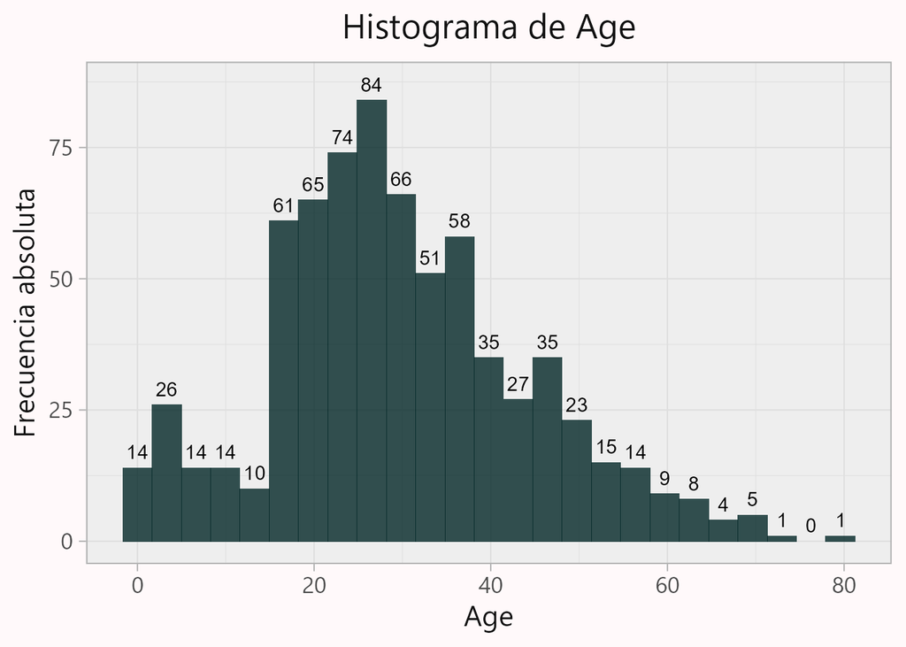

En apariencia, la distribución de edad de los pasajeros es bimodal, con grupos bien definidos de población de menores y de adultos. El primer grupo etáreo alcanzaría el 19% de los pasajeros. Por supuesto, esto correlaciona con la distribución de títulos de los pasajeros:

```r
extract_title <- function(x) {
  x %>%
    stringr::str_extract("Mr\\.? |Mrs\\.?|Miss\\.?|Master\\.?") %>%
    stringr::str_remove("\\.") %>%
    if_else(is.na(.), "Other", .)
}

titanic_train %>%
  mutate(Title = if_else(is.na(extract_title(Name)), "Other", extract_title(Name))) %>%
  group_by(Title) %>%
  summarize(across(Age, list("Min Age" = min, "Max Age" = max), na.rm = TRUE, .names = "{.fn}"))
```

```
## # A tibble: 5 x 3
##   Title    `Min Age` `Max Age`
##   <chr>        <dbl>     <dbl>
## 1 "Master"      0.42        12
## 2 "Miss"        0.75        63
## 3 "Mr "        11           80
## 4 "Mrs"        14           63
## 5 "Other"      23           70
```

Los grupos con títulos masculinos están bien caracterizados, y una estimación de la edad por la media del grupo sería más adecuada que estimar por la media de la muestra completa. Sin embargo, los títulos femeninos presentan solapamiento.

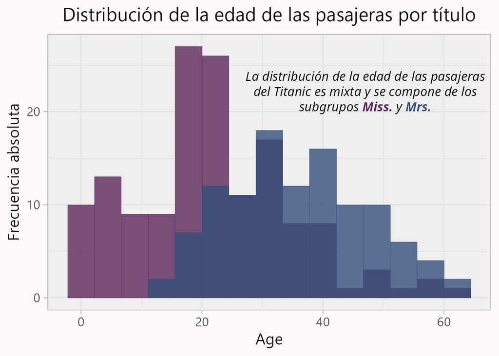

Se observa que pese al traslape de las distribuciones, la edad sí puede ser caracterizada por el título de la pasajera. Finalmente, los valores faltantes de edad serán imputados con el algoritmo *KNN* y utilizando la *distancia de Gower*, cuyos predictores serán las variables `Title`, `Sex`, `SibSp` y `Parch`.

Finalmente, el conjunto de prueba presenta un valor faltante en la columna `Fare`. Este será imputado con los vecinos más cercanos utilizando `Age`, `Sex`, `Embarked` y `Pclass`.

### Imputación de los valores faltantes

Para culminar el tratamiento de los datos faltantes, las transformaciones e imputaciones se llevarán a cabo utilizando el framework de machine learning `tidymodels`, porque facilita la incorporación de las etapas de procesamiento de datos en el flujo de trabajo de data science.

El primer paso es separar los datos de entrenamiento en entrenamiento y validación, con 3/4 de los datos en el conjunto de entrenamiento. Luego, se crea un objeto de *receta* que contendrá todas las etapas del procesamiento deseadas. Esta receta se usará posteriormente para crear el dataset al que se ajustará un modelo de *random forest*, por ésto el nombre de `rf_recipe`. Después, se incorporan la imputación por la moda de `Embarked`, la transformación de la columna `Cabin`, la creación de la columna `Title` y la imputación con KNN de la columna `Age`.

Random forest no requiere preprocesamiento exhaustivo sobre los datos de entrenamiento, tales como transformaciones matemáticas (logaritmo de `Fare` o z-score de `Age`) y creación de variables dummy. Además, cabe destacar que `bake()` aplica las transformaciones de la receta a nuevos conjuntos de datos; si `new_data = NULL` entonces retorna los datos de entrenamientos transformados; si `new_data = titanic_test`, se aplican las transformaciones **calculadas sobre el conjunto de entrenamiento** para retornar el conjunto de prueba transformado, evitando así data leakage.

```r
set.seed(123)
titanic_split <- initial_split(titanic_train, strata = Survived)
titanic_train <- training(titanic_split)
titanic_val <- testing(titanic_split)

rf_recipe <-
  recipe(~ ., data = titanic_train) %>%
  step_impute_mode(Embarked) %>%
  step_mutate(Cabin = if_else(is.na(Cabin), "Yes", "No"),
              Title = extract_title(Name)) %>%
  step_impute_knn(Age, impute_with = c("Title", "Sex", "SibSp", "Parch")) %>%
  step_impute_knn(Fare, impute_with = c("Age", "Sex", "Embarked", "Pclass"))

prep_recipe <- prep(rf_recipe)
train_processed <- bake(prep_recipe, new_data = NULL)
val_processed <- bake(prep_recipe, new_data = titanic_val %>%
                         mutate(across(where(is.character), as.factor)))
test_processed <- bake(prep_recipe, new_data = titanic_test %>%
                         mutate(across(where(is.character), as.factor)))
```

### Resampling y afinación de hiperparámetros

```r
set.seed(123)
titanic_folds <- vfold_cv(train_processed, v = 10)
```

Los errores de entrenamiento y validación serán calculados para cada uno de los subconjuntos en `titanic_folds`, estimando el error de validación como la media de los 10 errores de validación parciales.

Paralelamente, se declara la especificación del modelo de random forest utilizando engine del paquete `ranger`, en *modo clasificación*. Los hiperparámetros a afinar se definen a continuación:

- **mtry**: un entero para el número de predictores que son muestreados aleatoriamente en cada separación al crear los modelos de árbol.
- **min_n**: un entero para el número mínimo de puntos necesarios en un nodo para que pueda seguir dividiéndose.
- **trees**: un entero para el número de árboles contenidos en el ensamblaje.

```r
rf_spec <-
  rand_forest(
    mtry = tune(),
    min_n = tune(),
    trees = tune()
  ) %>%
  set_mode("classification") %>%
  set_engine("ranger", importance = "impurity")
```

```r
set.seed(123)
rf_grid <-
  grid_latin_hypercube(
    rf_spec %>%
      parameters() %>%
      update(mtry = range_set(mtry(), c(1, 9)),
             trees = range_set(trees(), c(200, 2000))),
    size = 200
  )
```

Una vez se tienen los componentes más importantes del framework de tidymodels (preprocesamiento, especificación de modelo, resampling y mecanismo de afinación de hiperparámetros), se procede a crear un workflow que los haga interactuar.

```r
rf_formula <- formula(Survived ~ Pclass + Sex + Age + SibSp + Parch + Fare + Cabin + Embarked + Title)
rf_wf <-
  workflow() %>%
  add_model(rf_spec) %>%
  add_formula(rf_formula)
```

Afinar 200 combinaciones de hiperparámetros en 10 subconjuntos de datos implica ajustar 2000 veces el modelo de random forest, con una cantidad de árboles que varía entre 200 y 2000. Para acelerar los cálculos, se permite que tidymodels acceda a los múltiples cores que tiene el computador mediante computación paralela, con `doParallel`.

```r
doParallel::registerDoParallel()
set.seed(123)
rf_res <- tune_grid(
  rf_wf,
  resamples = titanic_folds,
  grid = rf_grid,
  control = control_resamples(save_pred = TRUE)
)
```

> Observación: las métricas de la matriz de confusión son computadas con un umbral de clasificación de 0.50.

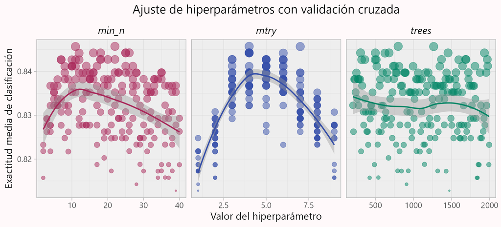

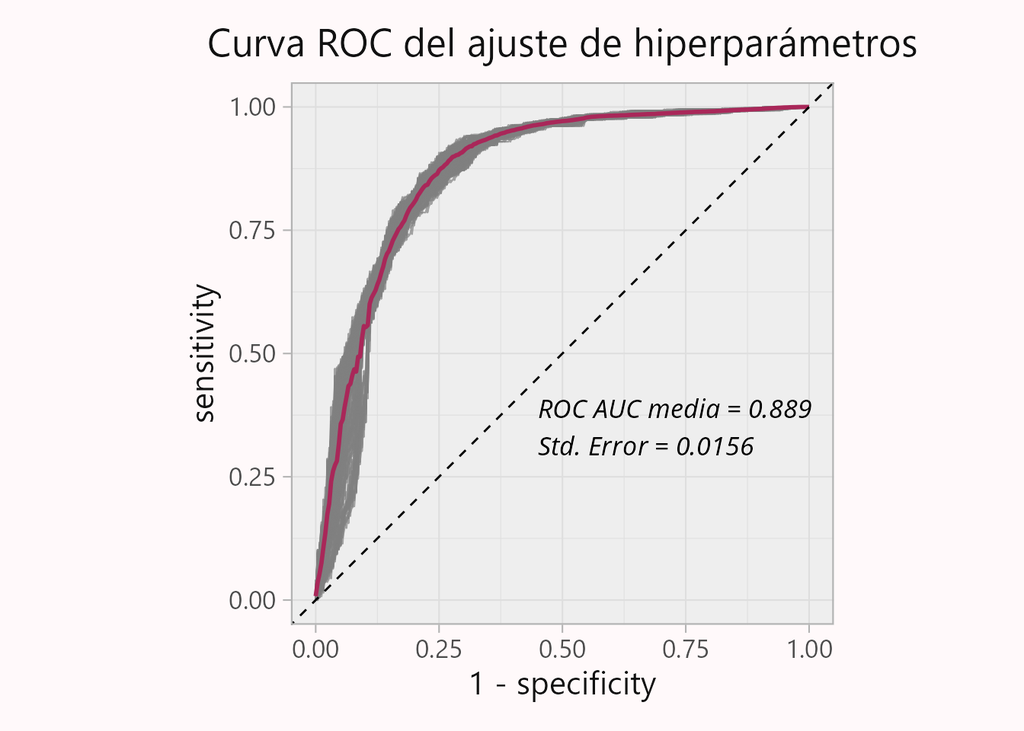

Sin embargo, prevalece la pregunta: para obtener el mejor conjunto de hiperparámetros ¿conviene optimizar accuracy o el área bajo la curva ROC? Para descubrir qué métrica conviene utilizar, se ajustan dos modelos de random forest, con las configuraciones óptimas de hiperparámetros para accuracy y área bajo la curva ROC, respectivamente.

```r
best_accuracy <- select_best(rf_res, metric = "accuracy")
best_roc <- select_best(rf_res, metric = "roc_auc")
final_wf_accuracy <- rf_wf %>% update_model(finalize_model(rf_spec, best_accuracy))
final_wf_roc <- rf_wf %>% update_model(finalize_model(rf_spec, best_roc))
set.seed(123)
rf_fit_accuracy <- fit(final_wf_accuracy, data = train_processed)
set.seed(123)
rf_fit_roc <- fit(final_wf_roc, data = train_processed)
```

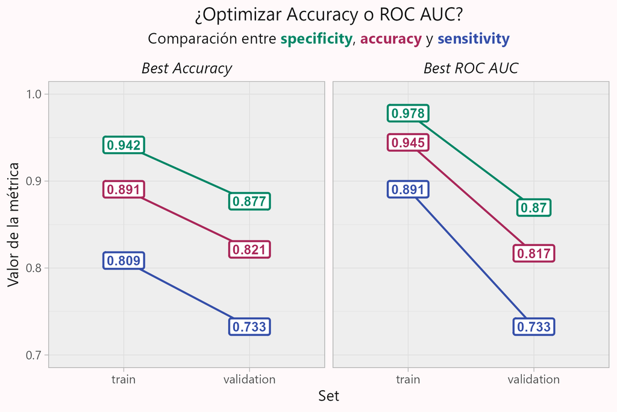

Se observa que ambos modelos tienden a sobreajustarse. La configuración para el mejor accuracy sobreajusta menos que la configuración con mejor ROC AUC, porque la diferencia entre las métricas de desempeño calculadas en los conjuntos de entrenamiento y validación es menor. Por lo tanto, se escoge la configuración del mejor accuracy para realizar las predicciones sobre el conjunto de prueba.

### Análisis de los resultados

En el gráfico anterior se aprecia que el mejor modelo (**Best Accuracy**) tiene buen desempeño cuando clasifica pasajeros que no sobrevivieron (specificity), pero empeora al clasificar pasajeros que sobrevivieron (sensitivity). Esto puede deberse al desbalance que existe entre las clases 0 y 1 del factor `Survived` en el conjunto de entrenamiento, que es 62% contra 38%, respectivamente. La manera común de palear este desbalance es usando técnicas de muestreo con reemplazo de la clase minoritaria (*upsampling*) o muestreo de la clase mayoritaria, con tamaño muestral igual a la clase minoritaria (*downsampling*). En este documento se mantendrá el modelo tal cual está.

A continuación, se analiza la importancia de las variables para la predicción de supervivencia de los pasajeros.

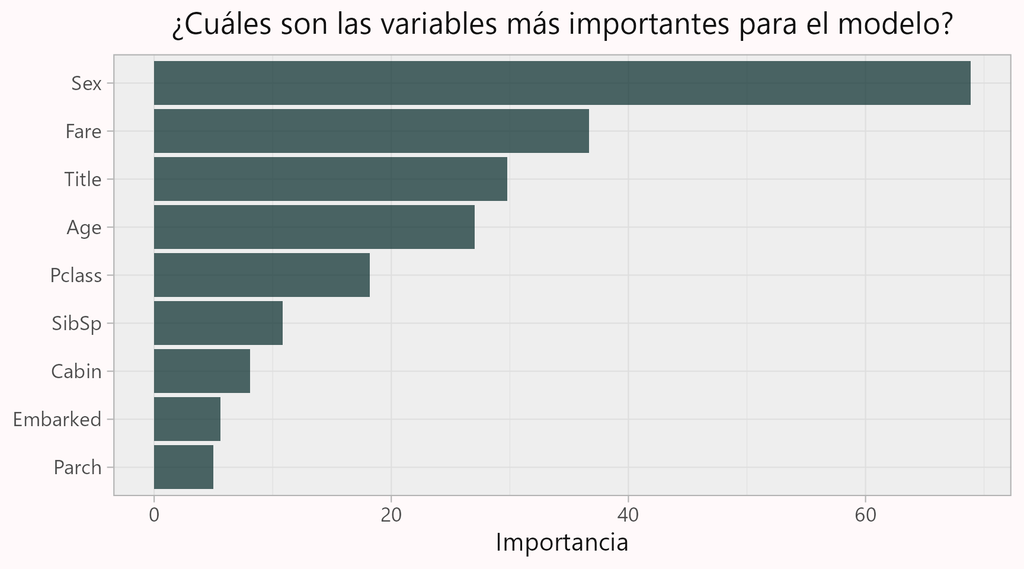

```r
train_processed %>% count(Sex, Survived)
```

```
## # A tibble: 4 x 3
##   Sex    Survived     n
##   <fct>  <fct>    <int>
## 1 female 0           59
## 2 female 1          176
## 3 male   0          352
## 4 male   1           80
```

De acuerdo con los datos de entrenamiento preprocesados, se puede calcular la probabilidad de que una pasajera sobreviva al accidente como la probabilidad condicional sobre la frecuencias observadas de ser mujer y haber sobrevivido. Sea $A:P(Survived=1)$ y $B:P(Sex=female)$

$$P(A\;|\;B) = \frac{P(A \; \bigcap \; B)}{P(B)} = \frac{176}{59 + 176} \approx 0.75.$$

Así, la probabilidad de que una pasajera sobreviva, dado que es mujer, es del 75%. Análogamente, se puede calcular la probabilidad de sobrevivir dado que el pasajero es hombre.

$$P(A \; | \; B^c) = \frac{P(A \; \bigcap \; B^c)}{P(B^c)} = \frac{80}{352 + 80} \approx 0.19.$$

Se observa que la probabilidad de que un pasajero hombre sobreviva es del 19%. Así, el modelo puede alcanzar una exactitud del 75% prediciendo que el pasajero sobrevive cuando es mujer, y 81% prediciendo que el pasajero no sobrevive cuando éste es hombre.

El mismo análisis puede llevarse a cabo con `Title`, al calcular la probabilidad condicional de supervivencia dado que el pasajero tiene un título determinado.

```r
train_processed %>%
  count(Title, Survived) %>%
  group_by(Title) %>%
  add_count(wt = n, name = "total_n") %>%
  ungroup() %>%
  filter(Survived == 1) %>%
  mutate(B_prob = total_n / sum(total_n),
         joint_prob = n / sum(total_n),
         conditional_prob = joint_prob / B_prob) %>%
  select(Title, conditional_prob) %>%
  pivot_wider(names_from = Title, values_from = conditional_prob)
```

```
## # A tibble: 1 x 5
##   Master  Miss `Mr `   Mrs Other
##    <dbl> <dbl> <dbl> <dbl> <dbl>
## 1  0.586 0.734 0.155 0.758   0.4
```

Evidentemente, los pasajeros con título Miss y Mrs, todas mujeres, tienen alta probabilidad de sobrevivir. Es interesante observar que los pasajeros de título Master (niños de hasta 12 años) tienen una probabilidad mucho más alta de sobrevivir respecto de los varones con más de 12 años.

Posteriormente, se analizan las distribuciones de `Fare` y `Age` para ver cómo influyen en la supervivencia de los pasajeros.

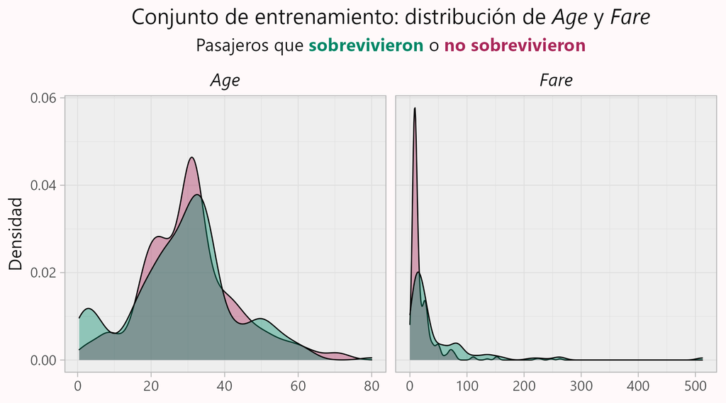

Respecto a lo anterior cabe preguntarse, ¿qué distribuciones ha asumido el modelo para predecir supervivencia?

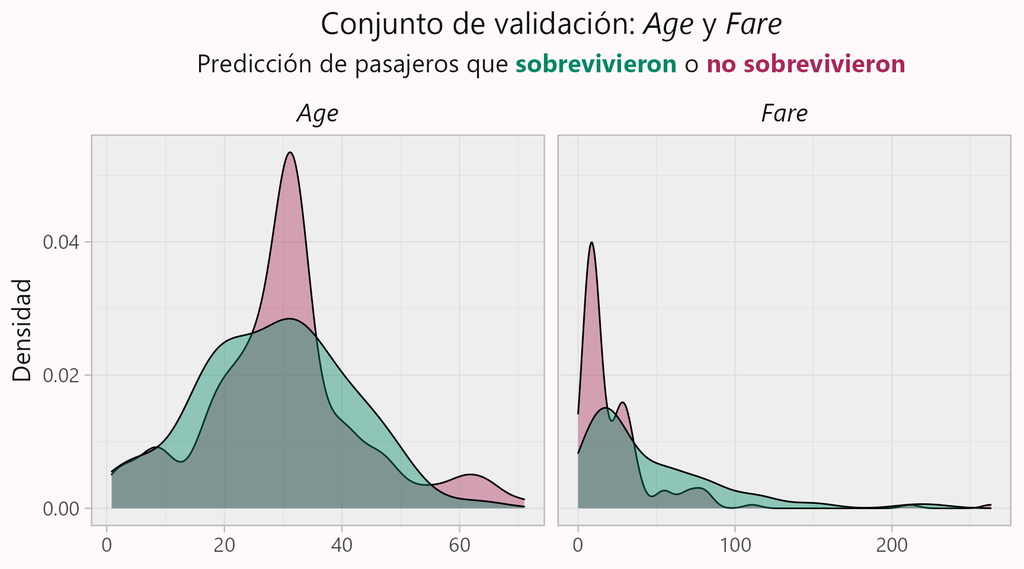

Interesantemente, ambas variables son menos asimétricas que en el conjunto de entrenamiento, pero sigue existiendo gran solapamiento entre las clases de supervivencia. Queda claro que el modelo aprendió que los pasajeros sobre 60 años tuvieron menos chances de sobrevivir. Al contrario, aquellos pasajeros que pagaron altas tarifas probablemente sobrevivieron.

### Predicción del conjunto de prueba

Previamente, se analizaron las cuatro variables más importantes para el modelo de clasificación de random forest. Ahora, se realizará la predicción para el conjunto de prueba, junto con la escritura de los resultados en formato csv.

```r
bind_cols(test_processed, predict(rf_fit_accuracy, test_processed)) %>%
  select(PassengerId, Survived = .pred_class) %>%
  write_csv(file = here("Machine Learning Avanzado", "titanic_test_pred.csv"))
```